# R 基础操作

宋骁

本文收集了我在学习R过程中觉得重要的知识点。

# 1 基本对象

模式强制转换：字符串：`as.character()`,整数：`as.integer()`,向量：`as.vector()`, 数据框：`as.data.frame()`

## 1.1 数组和矩阵

```r
library(dplyr)
library(ggplot2)
library(magrittr)
library(dplyr)
library(titanic)

mar<-c(652,1537,598,242,36,46,38,21,218,327,106,67)
caff.marital<-matrix(mar,nrow=3,byrow=T) #byrow=T通过行来填充
caff.marital
```

```
     [,1] [,2] [,3] [,4]
[1,]  652 1537  598  242
[2,]   36   46   38   21
[3,]  218  327  106   67
```

```r
#nrow和ncol中的一个被明确给出，则R会计算相应的另一个，从而使得矩阵中的数值与输入的值数目相匹配
x <- array(1:20, dim=c(4,5))
x
```

```
     [,1] [,2] [,3] [,4] [,5]
[1,]    1    5    9   13   17
[2,]    2    6   10   14   18
[3,]    3    7   11   15   19
[4,]    4    8   12   16   20
```

```r
h <- c(1:24)
Z <- array(h, dim=c(3,4,2)) #创建3X4X2的数组
Z
```

```
, , 1

     [,1] [,2] [,3] [,4]
[1,]    1    4    7   10
[2,]    2    5    8   11
[3,]    3    6    9   12

, , 2

     [,1] [,2] [,3] [,4]
[1,]   13   16   19   22
[2,]   14   17   20   23
[3,]   15   18   21   24
```

```r
Z[,,2]#索引
```

```
     [,1] [,2] [,3] [,4]
[1,]   13   16   19   22
[2,]   14   17   20   23
[3,]   15   18   21   24
```

```r
vec <- as.vector(Z)
vec
```

```
 [1]  1  2  3  4  5  6  7  8  9 10 11 12 13 14 15 16 17 18 19 20 21 22 23
[24] 24
```

```r
# 数组命名
vector1 <- c(5,9,3)
vector2 <- c(10,11,12,13,14,15)
column.names <- c("COL1","COL2","COL3")
row.names <- c("ROW1","ROW2","ROW3")
matrix.names <- c("Matrix1","Matrix2")

result <- array(c(vector1,vector2),dim = c(3,3,2),dimnames = list(row.names,column.names,
   matrix.names))
result
```

```
, , Matrix1

     COL1 COL2 COL3
ROW1    5   10   13
ROW2    9   11   14
ROW3    3   12   15

, , Matrix2

     COL1 COL2 COL3
ROW1    5   10   13
ROW2    9   11   14
ROW3    3   12   15
```

```r
result[,,'Matrix2'] #索引
```

```
     COL1 COL2 COL3
ROW1    5   10   13
ROW2    9   11   14
ROW3    3   12   15
```

## 1.2 列表

- 列表（list）是一个以对象的有序集合构成的对象。列表中包含的对象又称为它的分量（components）。 分量可以是不同的模式或类型，如一个列表可以同时包括数值向量，逻辑向量，矩阵，复向量，字符数组，函数等等。

# 2 循环

`for`循环

```r
pp <- c("Peter", "Piper", "picked", "a", "peck", "of", "pickled", "peppers")
for(i in seq_along(pp)) print(pp[i])
```

```
[1] "Peter"
[1] "Piper"
[1] "picked"
[1] "a"
[1] "peck"
[1] "of"
[1] "pickled"
[1] "peppers"
```

# 3 `apply()`族函数

Tutorial on the R Apply Family

包括`sapply()`, `lapply()`, 和 `tapply()`

`lapply()`默认返回值是列表

`aggregate()`类似于`dplyr::group_by`

```r
sapply(iris, class)
```

```
Sepal.Length  Sepal.Width Petal.Length  Petal.Width      Species
   "numeric"    "numeric"    "numeric"    "numeric"     "factor"
```

# 4 `dplyr`处理缺失值

```r
stocks <- tibble(
year = c(2015, NA, 2015, 2015, NA, 2016, 2016),
qtr = c( 1, 2, NA, NA, 2, NA, 4),
return = c(1.88, 0.44, 0.35, 0.66, 0.92, 0.17, 3.40)
)
knitr::kable(stocks,caption = '数据概要')
```

Table 4.1: 数据概要

| year | qtr | return |
| --- | --- | --- |
| 2015 | 1 | 1.88 |
| NA | 2 | 0.44 |
| 2015 | NA | 0.35 |
| 2015 | NA | 0.66 |
| NA | 2 | 0.92 |
| 2016 | NA | 0.17 |
| 2016 | 4 | 3.40 |

缺失值重编码成其他值：

- 任务，将`qtr`等于`NA`的行的`year`变量重编码为`9999`
- `dplyr::recode`无法给出条件

```r
stocks %>% mutate(year= ifelse(is.na(qtr),9999,year))
```

```
# A tibble: 7 x 3
   year   qtr return
  <dbl> <dbl>  <dbl>
1  2015     1   1.88
2    NA     2   0.44
3  9999    NA   0.35
4  9999    NA   0.66
5    NA     2   0.92
6  9999    NA   0.17
7  2016     4   3.4
```

```r
stocks %>% mutate(year=case_when(
  is.na(qtr) ~ 9999,
  is.na(qtr)==F ~ year,
))
```

```
# A tibble: 7 x 3
   year   qtr return
  <dbl> <dbl>  <dbl>
1  2015     1   1.88
2    NA     2   0.44
3  9999    NA   0.35
4  9999    NA   0.66
5    NA     2   0.92
6  9999    NA   0.17
7  2016     4   3.4
```

```r
stocks %>% mutate(year=replace(year,is.na(qtr),9999))
```

```
# A tibble: 7 x 3
   year   qtr return
  <dbl> <dbl>  <dbl>
1  2015     1   1.88
2    NA     2   0.44
3  9999    NA   0.35
4  9999    NA   0.66
5    NA     2   0.92
6  9999    NA   0.17
7  2016     4   3.4
```

其他值重编码成缺失值：

- 使用`na_if`。但是无法给出条件。

```r
stocks %>% mutate(return=ifelse(year==2016,NA,return))
```

```
# A tibble: 7 x 3
   year   qtr return
  <dbl> <dbl>  <dbl>
1  2015     1   1.88
2    NA     2  NA
3  2015    NA   0.35
4  2015    NA   0.66
5    NA     2  NA
6  2016    NA  NA
7  2016     4  NA
```

```r
stocks %>% mutate(return=replace(return,year==2016,NA))
```

```
# A tibble: 7 x 3
   year   qtr return
  <dbl> <dbl>  <dbl>
1  2015     1   1.88
2    NA     2   0.44
3  2015    NA   0.35
4  2015    NA   0.66
5    NA     2   0.92
6  2016    NA  NA
7  2016     4  NA
```

```r
stocks %>% mutate(return=na_if(return,year==2016))
```

```
# A tibble: 7 x 3
   year   qtr return
  <dbl> <dbl>  <dbl>
1  2015     1   1.88
2    NA     2   0.44
3  2015    NA   0.35
4  2015    NA   0.66
5    NA     2   0.92
6  2016    NA   0.17
7  2016     4   3.4
```

```r
stocks %>% mutate(year=na_if(year,2016))
```

```
# A tibble: 7 x 3
   year   qtr return
  <dbl> <dbl>  <dbl>
1  2015     1   1.88
2    NA     2   0.44
3  2015    NA   0.35
4  2015    NA   0.66
5    NA     2   0.92
6    NA    NA   0.17
7    NA     4   3.4
```

```r
stocks %>% mutate(return=na_if(year==2016,return))
```

```
# A tibble: 7 x 3
   year   qtr return
  <dbl> <dbl> <lgl>
1  2015     1 FALSE
2    NA     2 NA
3  2015    NA FALSE
4  2015    NA FALSE
5    NA     2 NA
6  2016    NA TRUE
7  2016     4 TRUE
```

# 5 数据合并

- `cbind()`把矩阵横向合并成一个大矩阵（列方式），而`rbind()`是纵向合并（行方式）。
- `dplyr`的`join`方法

```r
myData <- data.frame(
    nation=rep(c('USA','Japan','Libya'),3),
    subregion=rep(c('north','south','middle'),each=3),
    Awesomeness=rnorm(9)
    )
myData
```

```
  nation subregion Awesomeness
1    USA     north  -0.8819829
2  Japan     north   1.5213970
3  Libya     north  -0.3247084
4    USA     south   1.1091897
5  Japan     south  -1.3847303
6  Libya     south  -1.8545281
7    USA    middle   0.7358164
8  Japan    middle  -1.0390018
9  Libya    middle   0.5984367
```

```r
countryData <- data.frame(
    nation=c('USA','Japan','Libya','Belarus'),
    NumberOfSquid=c(rpois(4,10))
    )
countryData
```

```
   nation NumberOfSquid
1     USA             7
2   Japan            18
3   Libya            12
4 Belarus             9
```

```r
myData %>% full_join(countryData,copy=T)
```

```
    nation subregion Awesomeness NumberOfSquid
1      USA     north  -0.8819829             7
2    Japan     north   1.5213970            18
3    Libya     north  -0.3247084            12
4      USA     south   1.1091897             7
5    Japan     south  -1.3847303            18
6    Libya     south  -1.8545281            12
7      USA    middle   0.7358164             7
8    Japan    middle  -1.0390018            18
9    Libya    middle   0.5984367            12
10 Belarus      <NA>          NA             9
```

```r
myData %>% left_join(countryData,copy=T)
```

```
  nation subregion Awesomeness NumberOfSquid
1    USA     north  -0.8819829             7
2  Japan     north   1.5213970            18
3  Libya     north  -0.3247084            12
4    USA     south   1.1091897             7
5  Japan     south  -1.3847303            18
6  Libya     south  -1.8545281            12
7    USA    middle   0.7358164             7
8  Japan    middle  -1.0390018            18
9  Libya    middle   0.5984367            12
```

```r
library(plyr)
join(myData, countryData, by='nation', type='left', match='all')
```

```
  nation subregion Awesomeness NumberOfSquid
1    USA     north  -0.8819829             7
2  Japan     north   1.5213970            18
3  Libya     north  -0.3247084            12
4    USA     south   1.1091897             7
5  Japan     south  -1.3847303            18
6  Libya     south  -1.8545281            12
7    USA    middle   0.7358164             7
8  Japan    middle  -1.0390018            18
9  Libya    middle   0.5984367            12
```

# 6 使用`devtools`本地安装R包

以`REmap`包为例,从[github](https://github.com/)上下载压缩包后，使用`install_local`安装。

```r
library(devtools)
install_github('lchiffon/REmap') #可以试试，但基本不好使
install_local("C:/Users/lenovo/Desktop/REmap-master.zip") #设置正确的本地路径
```

# 7 [`magrittr`](https://magrittr.tidyverse.org/)管道操作符

[张丹的文章](https://mp.weixin.qq.com/s/wD2tK04qGJ8Qvb-sD0Nhcg)

`%T>%`

`%$%`

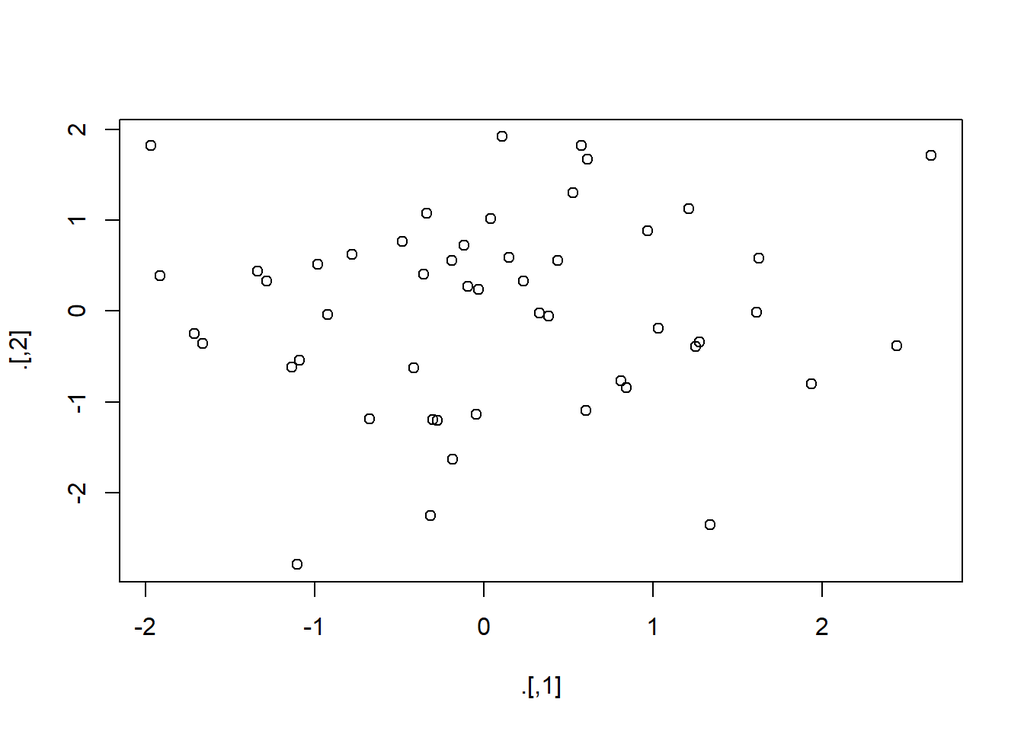

```
 num [1:50, 1:2] 1.627 0.576 0.604 2.44 -0.983 ...
```

```r
rnorm(100) %>%
matrix(ncol = 2) %T>%
plot() %>%
str()
```

```r
myData %$%
  table(nation,subregion)
```

```
       subregion
nation  middle north south
  Japan      1     1     1
  Libya      1     1     1
  USA        1     1     1
```

```r
mar <-
myData %$%
  table(nation,subregion) %>%
  as.data.frame()
```

# 8 函数

- 自己编写一个绘制交互表图形的函数`plot_table`。其中`x`为行向量，`y`为列向量，`xlab`为行标签，`ylab`为列标签。

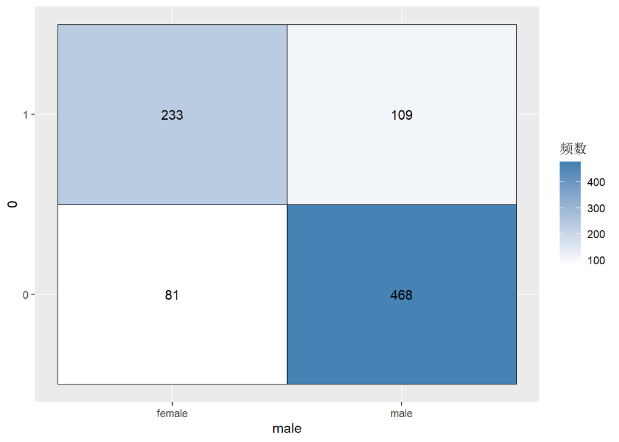

```r
plot_table <- function(x,y,xlab=x,ylab=y){
  mar <- as.data.frame(table(x,y))
  ggplot2::ggplot(mar,aes(mar[,1],mar[,2])) +
  geom_tile(aes(fill=Freq),color='black') +
  scale_fill_gradient(low='white',high = 'steel blue')+
  geom_text(aes(label = Freq)) + labs(fill="频数",x=xlab,y=ylab)
}

data("titanic_train")
titanic <- titanic_train %>%
  as.data.frame()

titanic %$%
plot_table(Sex,Survived)
```

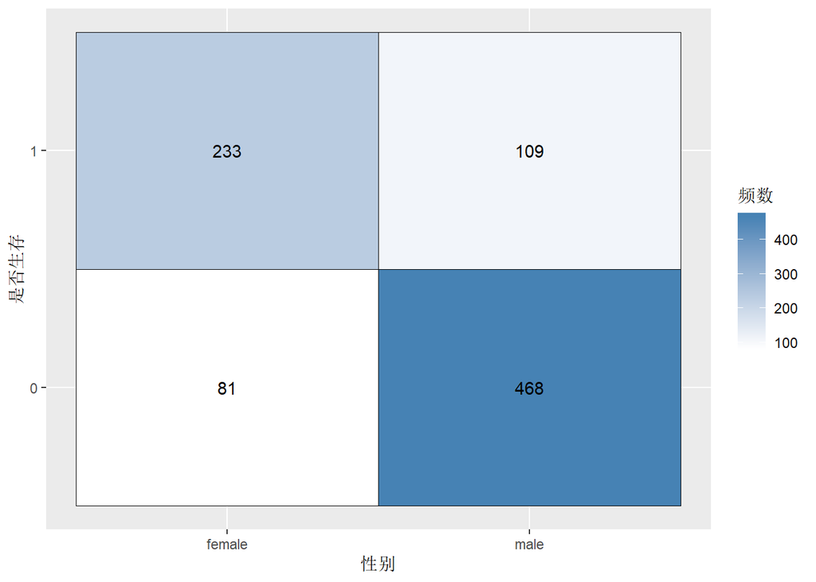

```r
titanic %$%
plot_table(Sex,Survived,"性别","是否生存")
```

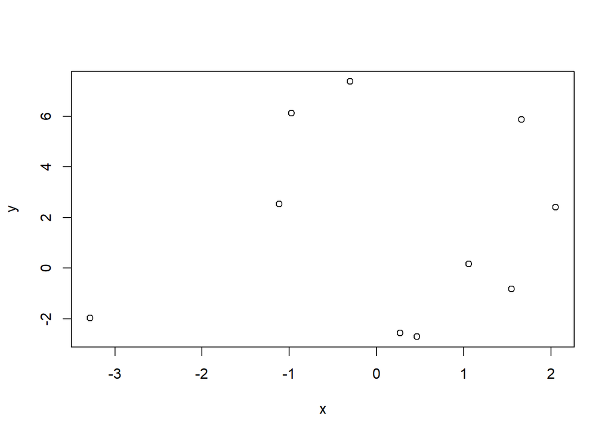

```
 [1]  4.454001  7.065929 -2.293605  5.146202  1.222645 -5.259875 -2.248780
 [8]  1.409102  7.520728  0.725593
```

```r
scattplot <- function(x,y){
  plot(x,y)
  return(x+y)
}
x <- rnorm(10)
y <- rnorm(10,2,3)
scattplot(x,y)
```

# 9 导出Stata文件

```r
library(foreign)
write.dta(`2011`,'C:/Users/201108.dta')
```

# 10 样条

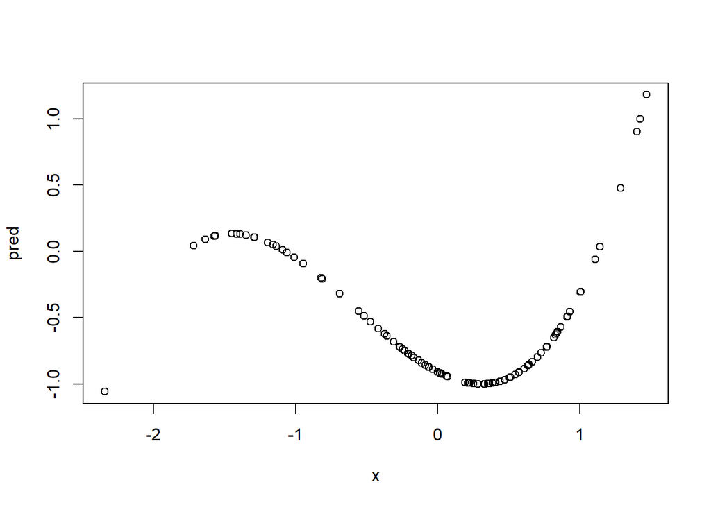

```r
library(splines)
n = 100
x = rnorm(n)
## Some non-linear function of x
p = plogis(2 * cos(5 * x) - 1)
y = rbinom(n, 1, p)

model = glm(y ~ bs(x), family = binomial())
pred = predict(model, bs(x))
plot(x, pred)
```

```r
require(stats); require(graphics)
bs(women$height, df = 5)
```

```
                 1           2           3            4           5
 [1,] 0.000000e+00 0.000000000 0.000000000 0.000000e+00 0.000000000
 [2,] 4.534439e-01 0.059857872 0.001639942 0.000000e+00 0.000000000
 [3,] 5.969388e-01 0.203352770 0.013119534 0.000000e+00 0.000000000
 [4,] 5.338010e-01 0.376366618 0.044278426 0.000000e+00 0.000000000
 [5,] 3.673469e-01 0.524781341 0.104956268 0.000000e+00 0.000000000
 [6,] 2.001640e-01 0.595025510 0.204719388 9.110787e-05 0.000000000
 [7,] 9.110787e-02 0.566326531 0.336734694 5.830904e-03 0.000000000
 [8,] 3.125000e-02 0.468750000 0.468750000 3.125000e-02 0.000000000
 [9,] 5.830904e-03 0.336734694 0.566326531 9.110787e-02 0.000000000
[10,] 9.110787e-05 0.204719388 0.595025510 2.001640e-01 0.000000000
[11,] 0.000000e+00 0.104956268 0.524781341 3.673469e-01 0.002915452
[12,] 0.000000e+00 0.044278426 0.376366618 5.338010e-01 0.045553936
[13,] 0.000000e+00 0.013119534 0.203352770 5.969388e-01 0.186588921
[14,] 0.000000e+00 0.001639942 0.059857872 4.534439e-01 0.485058309
[15,] 0.000000e+00 0.000000000 0.000000000 0.000000e+00 1.000000000
attr(,"degree")
[1] 3
attr(,"knots")
33.33333% 66.66667%
 62.66667  67.33333
attr(,"Boundary.knots")
[1] 58 72
attr(,"intercept")
[1] FALSE
attr(,"class")
[1] "bs"     "basis"  "matrix"
```

```r
summary(fm1 <- lm(weight ~ bs(height, df = 5), data = women))
```

```
Call:
lm(formula = weight ~ bs(height, df = 5), data = women)

Residuals:
     Min       1Q   Median       3Q      Max
-0.31764 -0.13441  0.03922  0.11096  0.35086

Coefficients:
                    Estimate Std. Error t value Pr(>|t|)
(Intercept)         114.8799     0.2167 530.146  < 2e-16 ***
bs(height, df = 5)1   3.4657     0.4595   7.543 3.53e-05 ***
bs(height, df = 5)2  13.0300     0.3965  32.860 1.10e-10 ***
bs(height, df = 5)3  27.6161     0.4571  60.415 4.70e-13 ***
bs(height, df = 5)4  40.8481     0.3866 105.669 3.09e-15 ***
bs(height, df = 5)5  49.1296     0.3090 158.979  < 2e-16 ***
---
Signif. codes:  0 '***' 0.001 '**' 0.01 '*' 0.05 '.' 0.1 ' ' 1

Residual standard error: 0.2276 on 9 degrees of freedom
Multiple R-squared:  0.9999,    Adjusted R-squared:  0.9998
F-statistic: 1.298e+04 on 5 and 9 DF,  p-value: < 2.2e-16
```

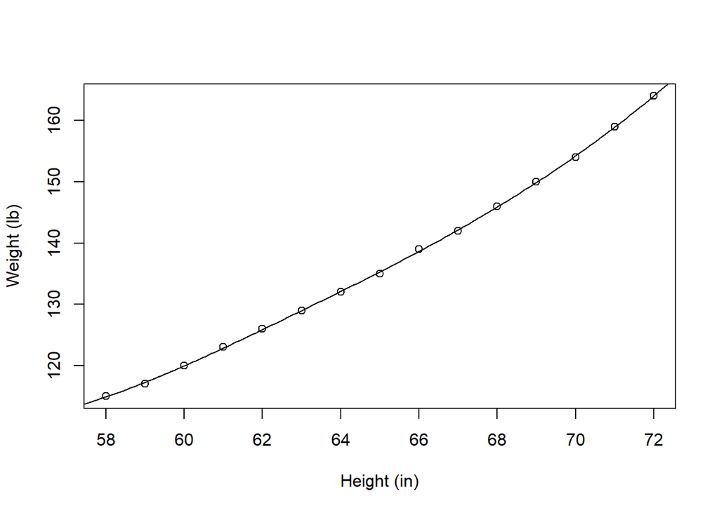

```r
## example of safe prediction
plot(women, xlab = "Height (in)", ylab = "Weight (lb)")
ht <- seq(57, 73, length.out = 200)
lines(ht, predict(fm1, data.frame(height = ht)))
```

# 11 广义可加模型

- Generalized Additive Models(GAM)

$$y = {\beta _0} + {f_1}({x_1}) + {f_2}({x_2}) + \cdot \cdot \cdot + {f_m}({x_m})$$
$f(x)$可以是样条、Lowess(局部多项式)等平滑方法。它和多元线性回归类似，但将$\beta x$替换为平滑函数。GAM使用backfitting algorithm使损失函数最小。

```r
library(mgcv)
set.seed(2) ## simulate some data...
dat <- gamSim(1,n=400,dist="normal",scale=2)
```

```
Gu & Wahba 4 term additive model
```

```r
b <- gam(y~s(x0)+s(x1)+s(x2)+s(x3),data=dat)
summary(b)
```

```
Family: gaussian
Link function: identity

Formula:
y ~ s(x0) + s(x1) + s(x2) + s(x3)

Parametric coefficients:
            Estimate Std. Error t value Pr(>|t|)
(Intercept)  7.83328    0.09878    79.3   <2e-16 ***
---
Signif. codes:  0 '***' 0.001 '**' 0.01 '*' 0.05 '.' 0.1 ' ' 1

Approximate significance of smooth terms:
        edf Ref.df      F  p-value
s(x0) 2.500  3.115  6.921 0.000129 ***
s(x1) 2.401  2.984 81.858  < 2e-16 ***
s(x2) 7.698  8.564 88.158  < 2e-16 ***
s(x3) 1.000  1.000  4.343 0.037806 *
---
Signif. codes:  0 '***' 0.001 '**' 0.01 '*' 0.05 '.' 0.1 ' ' 1

R-sq.(adj) =  0.715   Deviance explained = 72.5%
GCV = 4.0505  Scale est. = 3.9027    n = 400
```

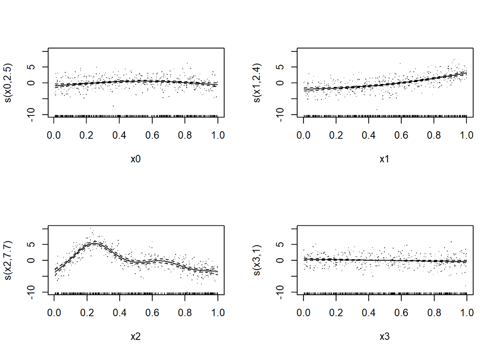

```r
plot(b,pages=1,residuals=TRUE)  ## show partial residuals
```

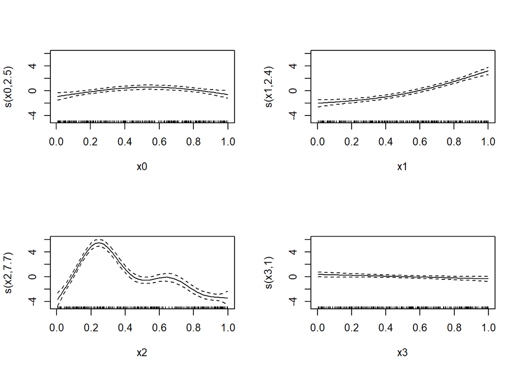

```r
plot(b,pages=1,seWithMean=TRUE) ## `with intercept' CIs
```

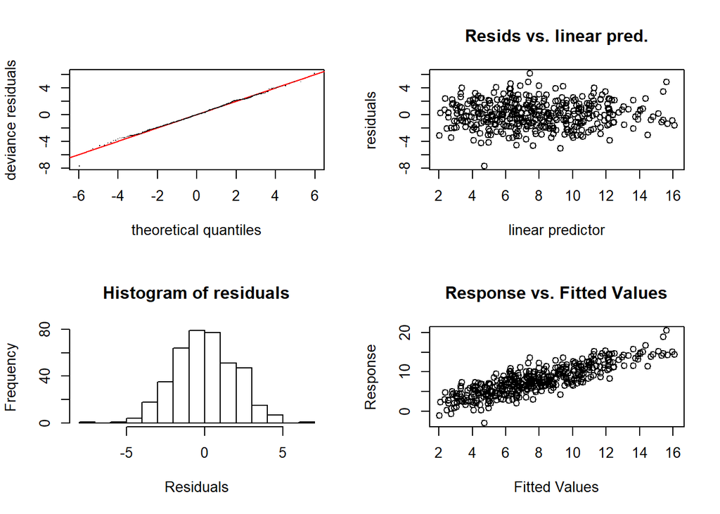

```
Method: GCV   Optimizer: magic
Smoothing parameter selection converged after 12 iterations.
The RMS GCV score gradient at convergence was 1.739918e-07 .
The Hessian was positive definite.
Model rank =  37 / 37

Basis dimension (k) checking results. Low p-value (k-index<1) may
indicate that k is too low, especially if edf is close to k'.

       k' edf k-index p-value
s(x0) 9.0 2.5    1.04    0.77
s(x1) 9.0 2.4    1.03    0.64
s(x2) 9.0 7.7    0.97    0.30
s(x3) 9.0 1.0    1.03    0.74
```

```r
## run some basic model checks, including checking
## smoothing basis dimensions...
gam.check(b)
```

```r
require(mgcv)
require(nlme)
b0 <- lme(travel~1,data=Rail,~1|Rail,method="REML")

b <- gam(travel~s(Rail,bs="re"),data=Rail,method="REML")

intervals(b0)
```

```
Approximate 95% confidence intervals

 Fixed effects:
               lower est.    upper
(Intercept) 44.33921 66.5 88.66079
attr(,"label")
[1] "Fixed effects:"

 Random Effects:
  Level: Rail
                   lower     est.    upper
sd((Intercept)) 13.27434 24.80547 46.35341

 Within-group standard error:
   lower     est.    upper
2.695007 4.020779 5.998747
```

```r
gam.vcomp(b)
```

```
Standard deviations and 0.95 confidence intervals:

          std.dev     lower     upper
s(Rail) 24.805465 13.274315 46.353510
scale    4.020779  2.695004  5.998753

Rank: 2/2
```

```r
anova(b)
```

```
Family: gaussian
Link function: identity

Formula:
travel ~ s(Rail, bs = "re")

Approximate significance of smooth terms:
          edf Ref.df     F p-value
s(Rail) 4.957  5.000 114.2  <2e-16
```

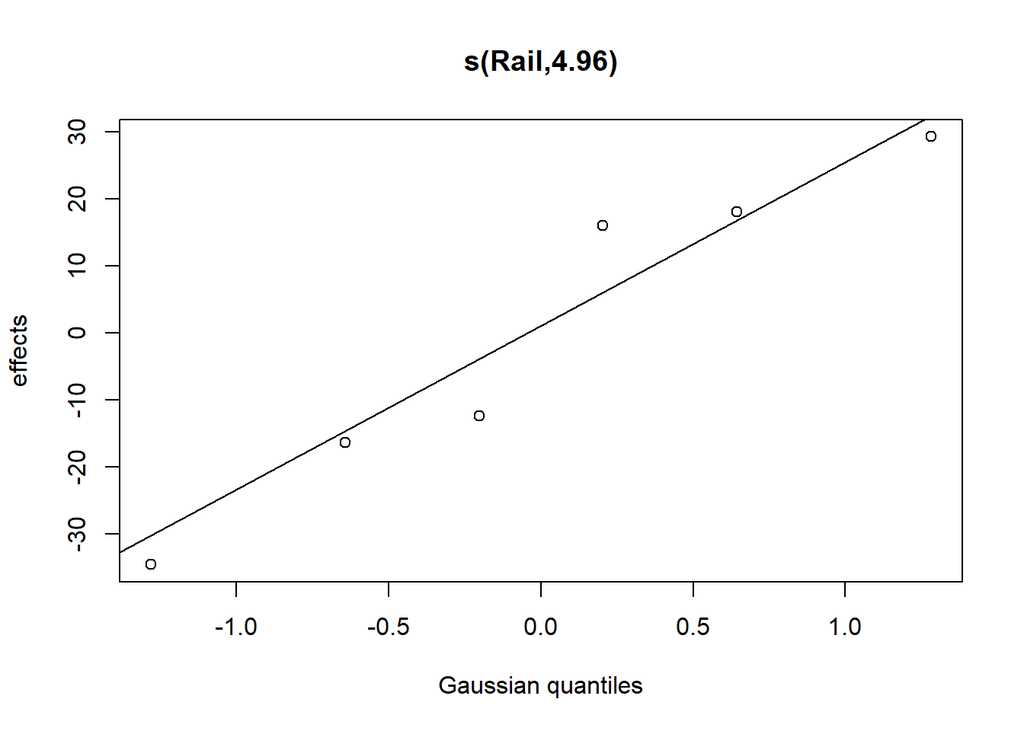

```r
plot(b)
```